# Progress Memo 2

Spotify Sequential Skip Prediction  
Data Science 2 with R (STAT 301-2) Final Project

Author

Sheena Tan

Published

February 28, 2024

**Github Repo Link**

https://github.com/stat301-2-2024-winter/final-project-2-sheena-tan

## Introduction

Spotify, an online music streaming platform with over 190 million active users and over 40 million tracks, faces a key challenge: how do you recommend the right music to right user? Out of a robust body of literature on recommendation systems, little work describes how users sequentially interact with recommended content. This gap is particularly evident in the music domain, where understanding when and why users skip tracks serves as crucial implicit feedback. The [Music Streaming Sessions Dataset](https://www.aicrowd.com/challenges/spotify-sequential-skip-prediction-challenge) was released by Spotify in 2018 to encourage research on this overlooked aspect of streaming.

This project hopes to provide an elementary solution (within the bounds of knowledge learned in class) to Spotify’s challenge: **Predict whether individual tracks encountered in a listening session will be skipped by a particular user.**

This problem is a **classification problem**, where the prediction output is a binary variable indicating if the track was skipped or not skipped. The data set provides information about each user’s listening session, including metadata and acoustic descriptors for all tracks encountered. This project uses the target variable `skipped`, a modified version of the original challenge’s `skip_2` field, where `skip_2` is a boolean variable (`TRUE`/`FALSE`) and `skipped` is a character variable (`yes`/`no`).

## Data Overview

### Data Source

Given laptop constraints, this project uses the miniature version of the [Music Streaming Sessions Dataset](https://www.aicrowd.com/challenges/spotify-sequential-skip-prediction-challenge), which is a minimally sized version of the original training set and track features provided by Spotify for challenge users to familiarize themselves with the data set.

### Data quality & complexity check

The complete data set contains 167,880 observations of 47 variables. Each observation corresponds to the playback of one track, for a total of 167,880 tracks listened to during 10,000 unique listening sessions, representing 50,704 unique tracks. For more information on the data used, please refer to the `README.me` in the `\data` folder.

### Potential data issues

When reading in the data, variables `context_type`, `hist_user_behavior_reason_start`, `hist_user_behavior_reason_end`, `mode`, `time_signature`, and `key` were retyped as factors. Analysis of the target variable revealed no major issues and proportions of songs skipped or not skipped were approximately even. There was no missingness in any of the variables.

## Methods

### Assessment metric

Models will be assessed using accuracy, and a confusion matrix will be produced.

### Analysis plan

An 80-20 training-test split was implemented using stratified sampling by target variable (2 strata). Resamples were constructed by taking the training dataset and applying repeated V-fold cross-validation (5 folds, 3 repeats) with stratification on the target variable with 2 strata.

The following model types will be created with hyperparameters to be tuned using a regular grid:

- naive bayes baseline model (`klaR` engine)
- logistic regression model (`glm` engine)
- K-nearest neighbors model (`kknn` engine)
  - Neighbors will be explored over $[1,25]$ with 7 levels
- Random forest (`ranger` engine)
  - Number of trees will be explored over $[500, 2000]$ with 4 levels
  - Number of randomly selected predictors to split on will be explored over $[1,5]$ with 5 levels
  - Minimum number of data points in a node for splitting will be explored over $[2,40]$ with 4 levels
- Boosted tree (`xgboost` engine)
  - Number of trees will be explored over $[100, 2000]$ with 6 levels
  - Number of randomly selected predictors to split on will be explored over $[1,5]$ with 5 levels
  - Minimum number of data points in a node for splitting will be explored over $[2,40]$ with 4 levels
  - Learning rate will be explored over $[-5,-0.2]$ with 10 levels (on log-10 scale)

The logistic model used the preprocessing stored in `spotify_recipe_lm`. Unneeded variables (`skip_1`, `skip_2`, `skip_3`, `not_skipped`, `session_id`, `track_id`, and variables with zero variance) were removed, predictor variables that are factors were dummy coded, and all numerical variables were standardized.

The k-nearest neighbors, random forest, and boosted tree models will use the preprocessing stored in `spotify_recipe_tree`. Unneeded variables (`skip_1`, `skip_2`, `skip_3`, `not_skipped`, `session_id`, `track_id`, and variables with zero variance) were removed, predictor variables that are factors were dummy coded, and all numerical variables were standardized.

## Model fitting

A naive bayes model was defined and fitted as a baseline model. A logistic model was also defined and fitted. A table containing each model’s assessment metric (accuracy) can be seen below.

| model | accuracy | std_err |
| --- | --- | --- |
| baseline | 0.8595365 | 7.744369e-4 |
| lm | 0.8742669 | 3.703331e-4 |

The baseline model had an accuracy of approximately **85.95%**, and the logistic model had an accuracy of approximately **87.43%**. Both of these accuracy measures are fairly high, with over 85% of the songs being correctly predicted as skipped or not skipped. The logistic model had a slightly higher accuracy than the baseline model with a lower standard error than the baseline model, suggesting that more complex models might be worthwhile to explore.

## Progress summary

I have completed data exploration, created an analysis plan, built out the project repository, and defined and fitted my first two models. From here, I will:

1. define and fit the tree-based models: boosted tree, random forest, and k-nearest neighbors;
2. compare the performance of the models to select a final model;
3. train the final model on the entire training data set;
4. test the final model and assess its performance;
5. visualize as necessary and write a final report of the results.

I am a bit concerned by how long some of the model fitting is taking, even when using parallel processing. Am I doing the parallel processing incorrectly? Fitting the baseline model took me **almost 40 minutes!** I recognize that I am using a much larger data set than we do in class, but I was not expecting it to take so long for the simplest model. Comparatively, it took about 10 minutes for the logistic model.

I am also wondering if there is a way to fit the model to each participant that won’t be too complex. Should I include `session_id` or `track_id` as predictive variables? Since music is so personalized, I would imagine that a model that works for each participant would be even more accurate.

## References

Spotify. (2018). *Spotify sequential Skip Prediction Challenge: Challenges*. AIcrowd. https://www.aicrowd.com/challenges/spotify-sequential-skip-prediction-challenge

Brost, B., Mehrotra, R., & Jehan, T. (2019, May). The music streaming sessions dataset. In *The World Wide Web Conference* (pp. 2594-2600).

## Updates to EDA

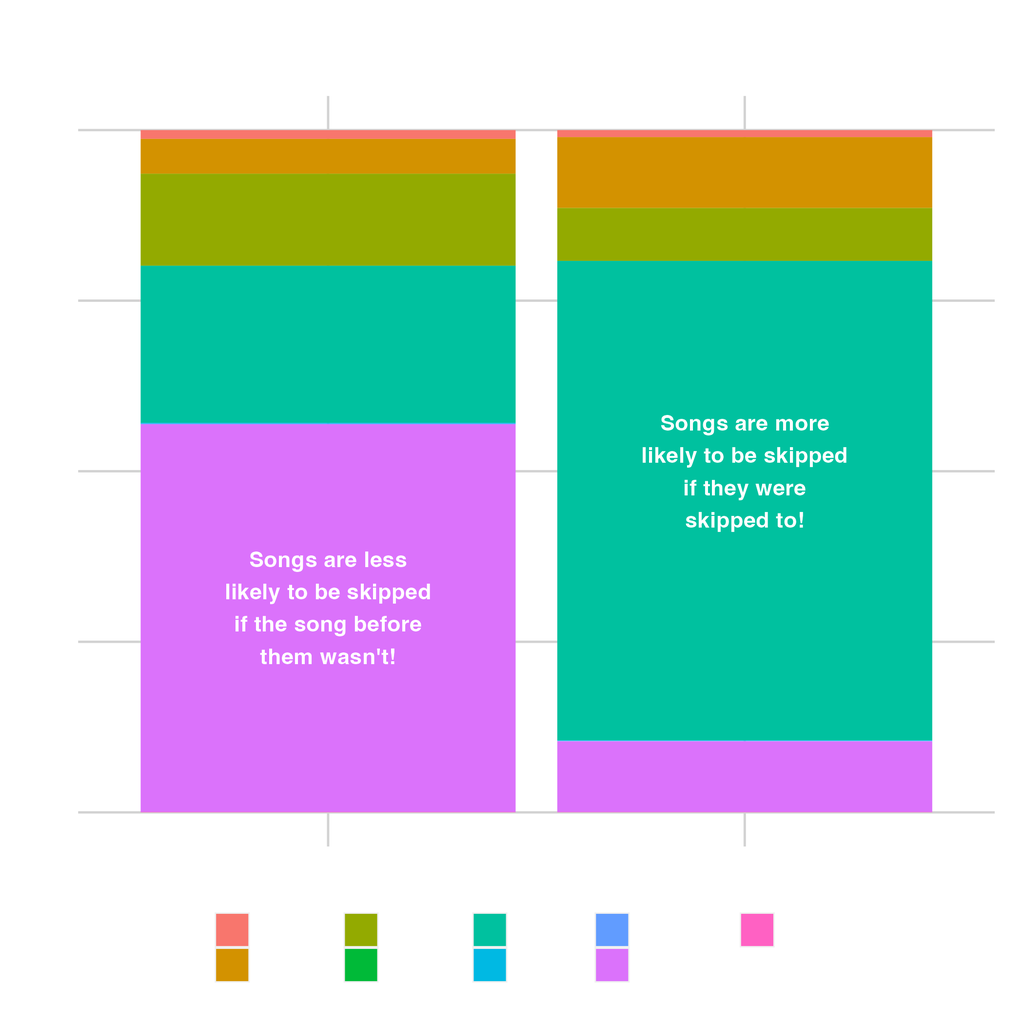

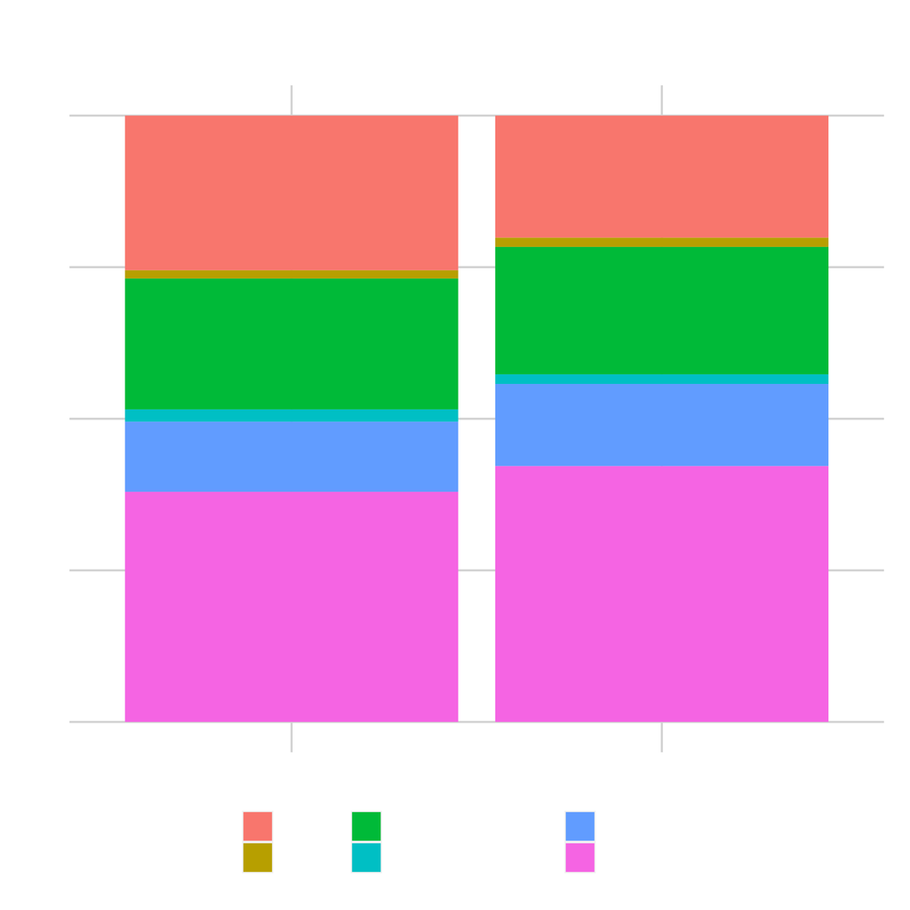

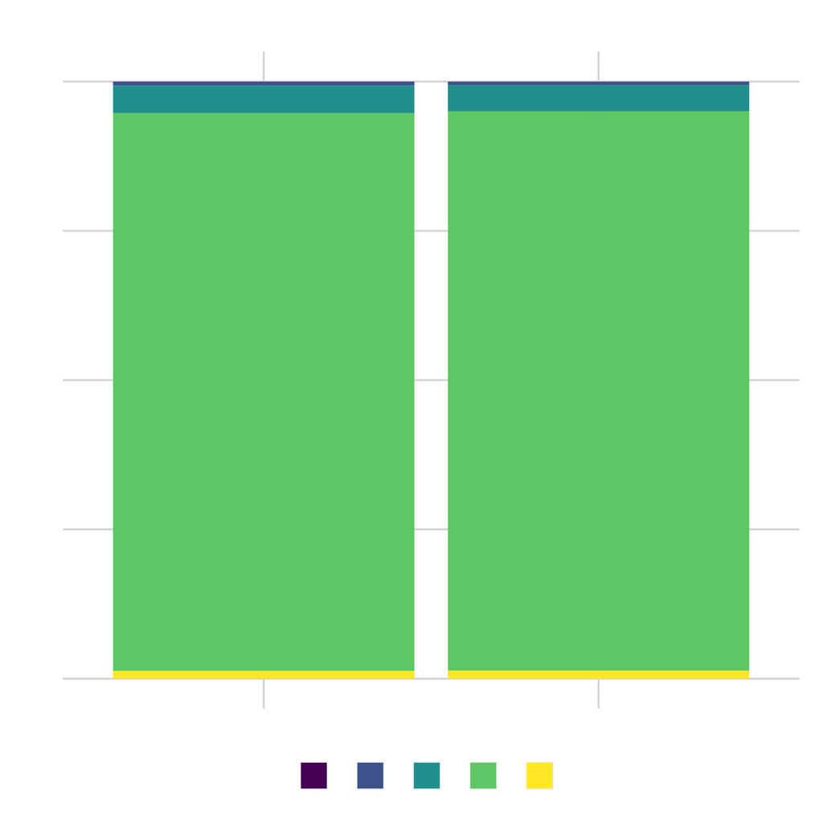

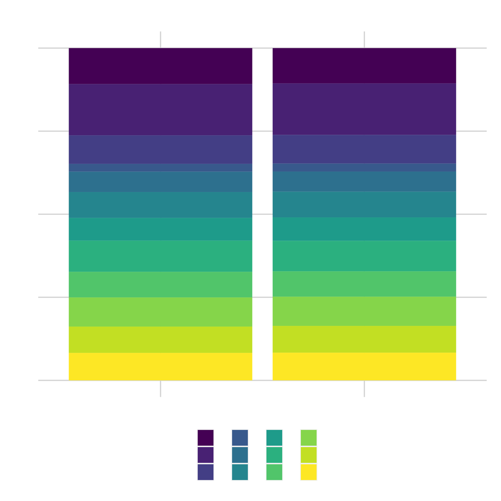

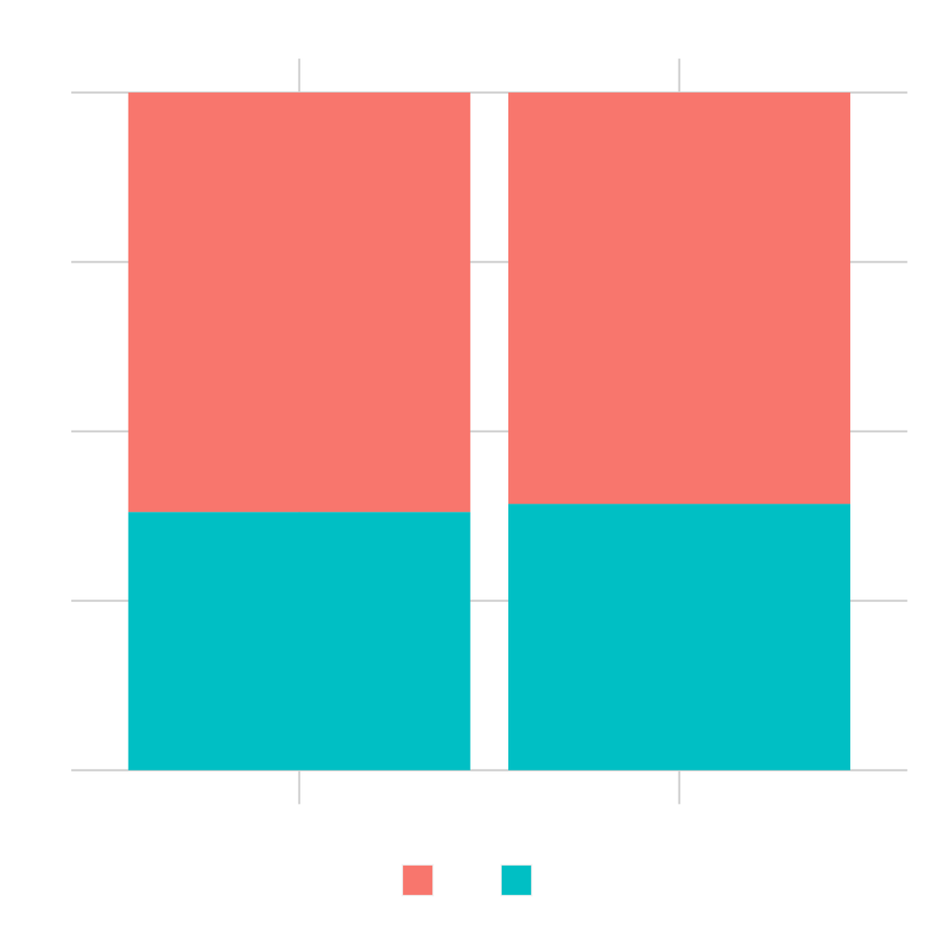

Figure 1: Other factor variables did not demonstrate differences by skip behavior

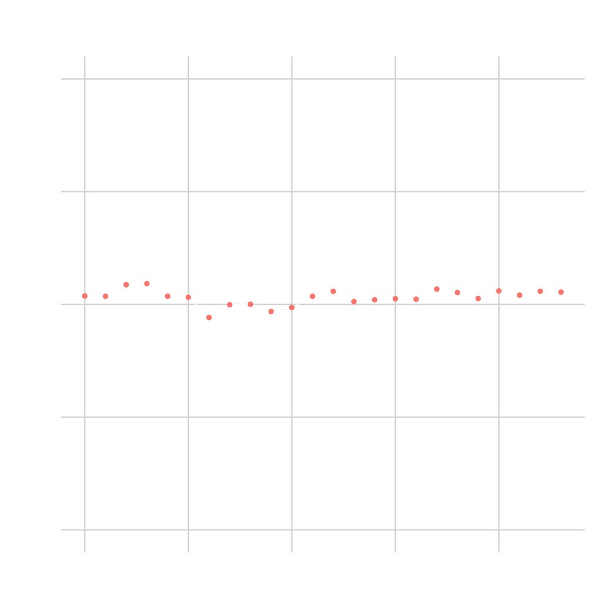

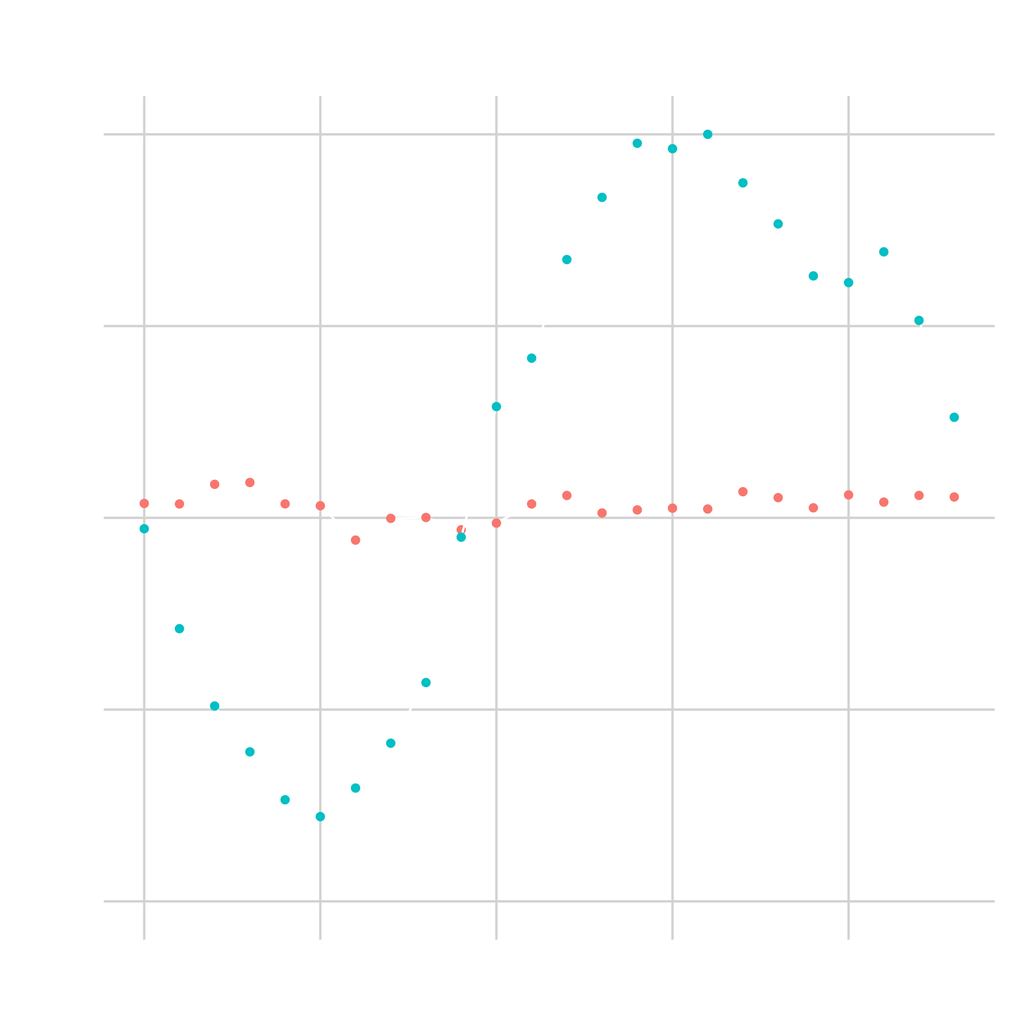